# Programming Homework

Statistics 98

محمدحسین کلهر

2020-02-05 16:46:22

[figure not shown]

# تمرین برنامه نویسی: بررسی آلودگی هوای آمریکا

> با استفاده از داده های آلودگی هوای آمریکا در سال ۲۰۱۸ به سوالات زیر پاسخ دهید. برای تصویرسازی از پکیج ggplot2 استفاده کنید.

> ابتدا کتابخانه های مورد استفاده را فرامیخوانیم. سپس با استفاده از دستور read_csv داده های مورد نظر را میخوانیم.

```r
library(readr)
library(ggplot2)
library(stats)
library(dplyr)
library(tidyr)

aqi = read_csv("~/Documents/Mohammad/Daneshgah/آمار ۹۸۱/RHW1/daily_aqi_by_county_2018.csv")
```

۱. آلوده ترین منطقه، چه منطقه ای بوده است؟ نمودار ستونی ۲۰ منطقه با بیشترین آلودگی را رسم کنید. این کار را برای ایالت ها نیز تکرار کنید.

برای بدست آوردن منطقه با بیشترین آلودگی، ابتدا کل داده را، با دستور group_by بر حسب منطقه گروه بندی می کنیم. سپس با استفاده از دستور summarise و پارامتر mean، میانگین آلودگی هر گروه را بدست می آوریم. سپس با استفاده از دستور arrange و پارامتر desc، مناطق را بر حسب میانگین آلودگی شان، به صورت نزولی مرتب می کنیم. بدین ترتیب سطر اول جدول، همان آلوده ترین منطقه بر اساس معیار میانگین است. بنابراین با استفاده از دستور slice(1:1) اولین سطر جدول را برمی گردانیم. برای کشیدن نمودار ۲۰ منطقه ای که بیشترین آلودگی را دارند، طبق قسمت قبل عمل می کنیم. این بار با استفاده از دستور slice(1:20)، ۲۰ سطر اول را می گیریم و به عنوان ورودی دیتای تابع ggplot می دهیم. محور x را نام مناطق و محور y را میانگین آلودگی مناطق، مقداردهی می کنیم. سپس با استفاده از دستور geom_bar نمودار ستونی را رسم می کنیم. برای ایالت ها نیز همین کار را تکرار می کنیم.

```r
aqi %>%
  group_by(`county Name`) %>%
  summarise(avgCounty=mean(AQI)) %>%
  arrange(desc(avgCounty)) %>%
  slice(1:1)
```

```
## # A tibble: 1 x 2
##   `county Name` avgCounty
##   <chr>             <dbl>
## 1 Hawaii             99.6
```

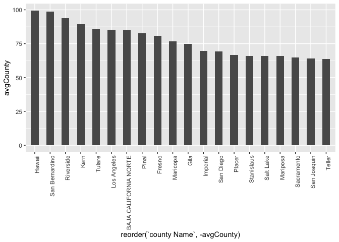

```r
aqi %>%
  group_by(`county Name`) %>%
  summarise(avgCounty=mean(AQI)) %>%
  arrange(desc(avgCounty)) %>%
  slice(1:20) %>%
  ggplot(aes(x=reorder(`county Name`,-avgCounty),y=avgCounty)) + geom_bar(stat="identity", width=0.5) + theme(axis.text.x = element_text(angle = 90, hjust = 1))
```

```r
aqi %>%
  group_by(`State Name`) %>%
  summarise(avgState=mean(AQI)) %>%
  arrange(desc(avgState)) %>%
  slice(1:1)
```

```
## # A tibble: 1 x 2
##   `State Name` avgState
##   <chr>           <dbl>
## 1 California       57.0
```

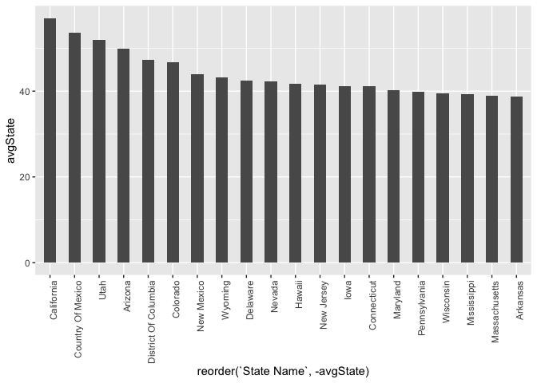

```r
aqi %>%
  group_by(`State Name`) %>%
  summarise(avgState=mean(AQI)) %>%
  arrange(desc(avgState)) %>%
  slice(1:20) %>%
  ggplot(aes(x=reorder(`State Name`,-avgState),y=avgState)) + geom_bar(stat="identity", width=0.5) + theme(axis.text.x = element_text(angle = 90, hjust = 1))
```

۲. نمودار جعبه ای آلودگی هوا را بر حسب درجه کیفی آلودگی هوا(Category) رسم کنید.

ابتدا متغیر Cateegory را با دستور as.Factor() به متغیر categorical تبدیل می کنیم. البته بر اساس مشاهده ی شخصی، اگر این دستور را هم اجرا نمی کردیم، خود R، آن را categorical در نظر می گرفت. سپس دیتافریم aqi را به عنوان پارامتر دیتای تابع ggplot ورودی می دهیم. همچنین محور ستون Category دیتافریم aqi را به عنوان محور x و میزان آلودگی (ستون AQI دیتافریم aqi) را به عنوان محور y قرار می دهیم. این کار را به کمک aqi$Category و aqi$AQI انجام می دهیم. سپس نمودار جعبه ای را با کمک تابع geom_boxplot() رسم می کنیم.

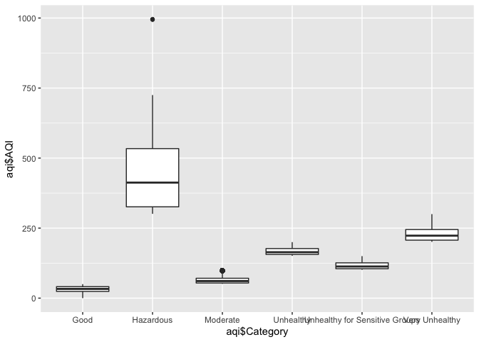

```r
aqi$Category = as.factor(aqi$Category)
g = ggplot(data = aqi, aes(x=aqi$Category, y=aqi$AQI))
g + geom_boxplot()
```

۳. نمودار خطی میانگین آلودگی هوای امریکا را بر حسب زمان رسم کنید.

ابتدا میانگین آلودگی در هر روز را بدست می آوریم. برای این کار کل داده را با دستور group_by بر حسب روز گروه بندی می کنیم. سپس با استفاده از دستور summarise و پارامتر mean، میانگین آلودگی هر گروه (روز) را بدست می آوریم. این دیتا را به عنوان ورودی data تابع ggplot می دهیم. روز ها را به عنوان محور x و میانگین آلودگی در هر روز (که در خط قبلی بدست آورده بودیم) را به عنوان محور y قرار می دهیم. سپس با استفاده از تابع geom_line نمودار خطی مورد نظر را رسم می کنیم.

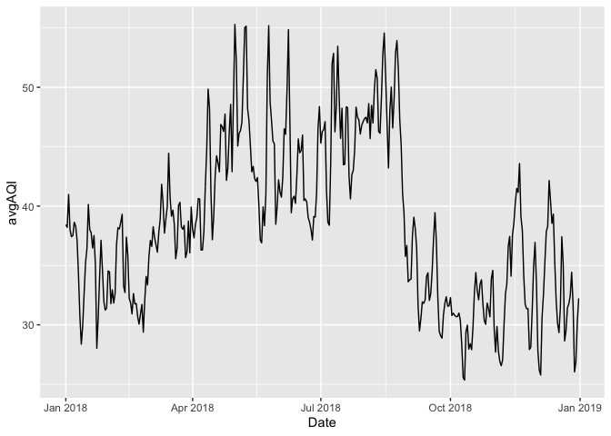

```r
aqi %>%
  group_by(Date) %>%
  summarise(avgAQI = mean(AQI)) %>%
  ggplot(aes(x=Date,y=avgAQI)) + geom_line()
```

۴. نمودار ستونی مهم ترین آلاینده های هوای واشنگتن را رسم کنید و بگویید که مهم ترین آلاینده هوای واشنگتن چه آلاینده ای است

باید ببینیم هر کدام از آلاینده ها چند بار به عنوان مهم ترین عامل آلودگی هوای واشنگتن، تکرار شده اند. برای این کار ابتدا با استفاده از دستور select دو ستون نام منطقه و مهم ترین عامل آلودگی را انتخاب می کنیم. سپس با استفاده از دستور filter داده های مربوز به منطقه ی washington رو جدا می کنیم. حالا با استفاده از دستور group_by داده ها را بر حسب نوع آلاینده گروه بندی می کنیم. در نهایت با استفاده از دستور count() تعداد تکرار هر آلاینده را حساب می کنیم. با استفاده از دستور arrange تعداد تکرارها را به صورت نزولی مرتب می کنیم و سطر اول را به عنوان خروجی نشان می دهیم. همانطور که از خروجی و نمودار قسمت بعد مشخص است، آلاینده ی Ozone با ۲۲۷۸ بار تکرار مهم ترین آلاینده ی هوای واشنگتن است.

```r
aqi %>%
  select(`county Name`,`Defining Parameter`) %>%
  filter(`county Name` == "Washington") %>%
  group_by(`Defining Parameter`) %>%
  count() %>%
  arrange(desc(n)) -> b
  b[1,]
```

```
## # A tibble: 1 x 2
## # Groups:   Defining Parameter [1]
##   `Defining Parameter`     n
##   <chr>                <int>
## 1 Ozone                 2278
```

برای کشیدن نمودار همان روند بالا را تکرار می کنیم. در نهایت با استفاده از دستور ggplot با قرار دادن آلاینده ها به عنوان محور x و تعداد تکرار (n) به عنوان محور y و دستور geom_bar نمودار ستونی را رسم می کنیم. دقت کنید ورودی پارامتر دیتای تابع ggplot همان جدول نام آلاینده ها با تعداد تکرار یعنی خروجی تابع count() است.

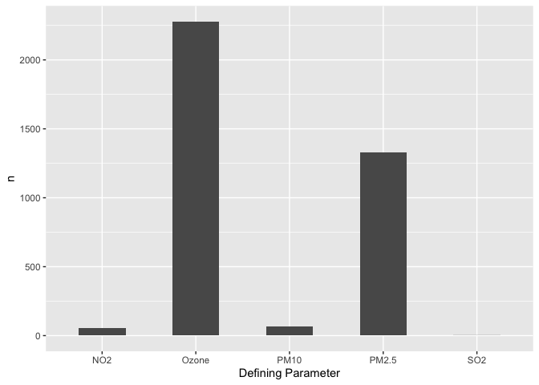

```r
aqi %>%
  select(`county Name`,`Defining Parameter`) %>%
  filter(`county Name` == "Washington") %>%
  group_by(`Defining Parameter`) %>%
  count() %>%
  ggplot(aes(x=`Defining Parameter`,y = n)) + geom_bar(stat = "identity", width = 0.5)
```

۵. می خواهیم بازه اطمینانی نود و پنج درصدی برای میانگین آلودگی هوای هر منطقه به دست بیاوریم. یک dataframe جدید بسازید که در آن مقابل اسم هر منطقه، ابتدا و انتهای بازه اطمینان در دو ستون مختلف نوشته شده باشد.

برای بدست آوردن یک بازه ی اطمینان برای میانگین آلودگی هر منطقه باید میانگین آلودگی هر منطقه، انحراف معیار هر منطقه و تعداد تکرار هر منطقه را داشته باشیم. برای این کار ابتدا با استفاده از دستور group_by، داده را بر حسب نام مناطق گروه بندی می کنیم. بنابراین grouped یک دیتافریم گروه بندی شده بر حسب مناطق است. حالا با استفاده از دستور summarise، میانگین، انحراف معیار و تعداد تکرار را بدست می آوریم و به ترتیب در بردار m، sd و n می ریزیم. حالا با توجه به فرمول بازه اطمینان ابتدا و انتهای هر بازه را بدست می آوریم و به ترتیب در بردار start و end می ریزیم. حالا با استفاده از دستور data.frame() دیتافریمی می سازیم که ستون اول آن نام مناطق، ستون دوم آن بردار start و ستون سوم آن بردار end است.

```r
aqi %>%
  group_by(`county Name`) -> grouped
grouped %>%
  summarise(meanAQI=mean(AQI)) -> m
grouped %>%
  summarise(sdAQI=sd(AQI)) -> s
grouped %>%
  count() -> n
start = m$meanAQI + qt(0.05/2,df=n$n-1)*s$sdAQI/sqrt(n$n)
end = m$meanAQI + qt((1-0.05)/2,df=n$n-1)*s$sdAQI/sqrt(n$n)
aqiCI = data.frame(`county Name`=m$`county Name`,start,end)
aqiCI
```

```
##               county.Name        start        end
## 1                     Ada  42.10346039 44.0190515
## 2                   Adair  38.03491506 39.5765820
## 3                   Adams  34.39018166 35.3460966
## 4                Adjuntas  13.20586029 15.2678024
## 5                   Aiken  36.79045515 38.3818430
## 6                 Alachua  33.63670508 34.7304332
## 7                 Alameda  53.59266236 56.3528562
## 8                 Alamosa  19.48361016 21.0914501
## 9                  Albany  44.46858710 45.5890452
## 10              Albemarle  34.54711109 36.0098735
## 11         Aleutians East  10.38108009 11.5048350
## 12              Alexander  39.46233063 41.0922812
## 13        Alexandria City   6.03501415  6.4853093
## 14                Allegan  39.84227683 42.1241445
```

[output cut: 801 more lines]

۶. با طراحی آزمون فرض، این ادعا را بررسی کنید:  
«در زمستان، هوا از تابستان آلوده تر است.»

با دو دیدگاه این سوال را بررسی می کنیم. ابتدا به کمک دستور filter داده های مربوط به زمستان (winter) و تابستان (summer) را بدست می آوریم. برای محاسبه ی p-value، ستون AQI داده های تابستان و زمستان را به تابع t.test() ورودی می دهیم. فرض صفر را این می گیریم که میانگین آلودگی در تابستان با میانگین آلودگی در زمستان برابر است. با توجه به میانگین آلودگی در تابستان و زمستان، فرض مقابل برابر با این است که میانگین آلودگی در تابستان بیشتر از میانگین آلودگی در زمستان است. پس مقدار پارامتر alternative را greater سِت می کنیم. همچنین conf.level را ۹۵٪ در نظر می گیریم. با توجه به این که p-value بسیار نزدیک به صفر است، فرض صفر را قویا رد می کنیم و فرض مقابل را می پذیریم. یعنی آلودگی در تابستان بیشتر یا مساوی آلودگی در زمستان است.

```r
aqi %>%
  filter(Date >= '2018-01-01') %>%
  filter(Date <= '2018-03-31') -> winter
mWinter = winter$AQI

aqi %>%
  filter(Date >= '2018-07-01') %>%
  filter(Date <= '2018-09-30') -> summer
mSummer = summer$AQI
hypoSW1 = t.test(mSummer,mWinter,alternative = "greater",conf.level = 0.95)
hypoSW1
```

```
##
##  Welch Two Sample t-test
##
## data:  mSummer and mWinter
## t = 61.789, df = 163497, p-value < 2.2e-16
## alternative hypothesis: true difference in means is greater than 0
## 95 percent confidence interval:
##  6.336894      Inf
## sample estimates:
## mean of x mean of y
##  42.35054  35.84034
```

```r
hypoSW1$p.value
```

```
## [1] 0
```

```r
aqi %>%
  filter(Date >= '2018-01-01') %>%
  filter(Date <= '2018-03-31') %>%
  group_by(`county Name`) %>%
  summarise(meanWinter=mean(AQI)) -> pWinter
aqi %>%
  filter(Date >= '2018-07-01') %>%
  filter(Date <= '2018-09-30') %>%
  group_by(`county Name`) %>%
  summarise(meanSummer=mean(AQI)) -> pSummer
merge(pSummer,pWinter,"county Name") -> merged
hypoMSW1=t.test(merged$meanSummer,merged$meanWinter,alternative = "greater",paired = TRUE,conf.level = 0.95)
hypoMSW1
```

```
##
##  Paired t-test
##
## data:  merged$meanSummer and merged$meanWinter
## t = 14.522, df = 799, p-value < 2.2e-16
## alternative hypothesis: true difference in means is greater than 0
## 95 percent confidence interval:
##  5.886325      Inf
## sample estimates:
## mean of the differences
##                6.639201
```

```r
hypoMSW1$p.value
```

```
## [1] 7.051271e-43
```

۷. با طراحی آزمون فرض، این ادعا را بررسی کنید:  
«آلودگی هوای زمستان و تابستان با هم تفاوت دارد.»  
نتیجه این آزمون را با بخش قبل مقایسه کنید.

در این سوال نیز مانند سوال قبل عمل می کنیم و همان فرض صفر را می گیریم. تفاوتی که این سوال با سوال قبل دارد این است که، چون در صورت سوال می خواهد ادعای «تفاوت داشتن آلودگی در زمستان و تابستان» را بررسی کنیم، بنابراین فرض مقابل این می شود که این دو میانگین برابر نیست. پس پارامتر alternative را two.sided سِت می کنیم. چون p-value خیلی کوچک می شود، فرض صفر را رد می کنیم. یعنی میانگین تابستان و زمستان با هم تفاوت دارند.

```r
hypoSW2 = t.test(mSummer,mWinter,alternative = "two.sided",conf.level = 0.95)
hypoSW2
```

```
##
##  Welch Two Sample t-test
##
## data:  mSummer and mWinter
## t = 61.789, df = 163497, p-value < 2.2e-16
## alternative hypothesis: true difference in means is not equal to 0
## 95 percent confidence interval:
##  6.303692 6.716709
## sample estimates:
## mean of x mean of y
##  42.35054  35.84034
```

```r
hypoSW2$p.value
```

```
## [1] 0
```

رویکرد جفت شده

```r
hypoMSW2=t.test(merged$meanSummer,merged$meanWinter,alternative = "two.sided",paired = TRUE,conf.level = 0.95)
hypoMSW2
```

```
##
##  Paired t-test
##
## data:  merged$meanSummer and merged$meanWinter
## t = 14.522, df = 799, p-value < 2.2e-16
## alternative hypothesis: true difference in means is not equal to 0
## 95 percent confidence interval:
##  5.741775 7.536627
## sample estimates:
## mean of the differences
##                6.639201
```

```r
hypoMSW2$p.value
```

```
## [1] 1.410254e-42
```

ابتدا با استفاده از دستور filter داده های مربوط به ایالت های تگزاس و میشیگان را جدا می کنیم به ترتیت در txs و mch می ریزیم. سپس ستون های مربوط به AQI را به ترتیب در txsAQI و mchAQI می ریزیم. حالا فرض صفر را این در نظر می گیریم که میانگین آلودگی تگزاس و میشیگان با هم برابر است. فرض مقابل هم به صورت پیش فرض two.sided در نظر می گیرم. با توجه به مقدار کوچک p-value، فرض صفر را رد می کنیم. یعنی میانگین آلودگی تگزاس و میشیگان تفاوت معنادار دارند. این نتیجه با توجه به اختلاف کم میانگین این دو ایالت، جالب است. نشان می دهد که این نزدیکی اتفاقی است.

```r
aqi %>%
  filter(`State Name`== "Texas") -> txs
aqi %>%
  filter(`State Name`== "Michigan") -> mch
txsAQI = txs$AQI
mchAQI = mch$AQI
hypoTM = t.test(txsAQI,mchAQI,alternative = "two.sided",conf.level = 0.95)
hypoTM
```

```
##
##  Welch Two Sample t-test
##
## data:  txsAQI and mchAQI
## t = -4.2503, df = 20338, p-value = 2.144e-05
## alternative hypothesis: true difference in means is not equal to 0
## 95 percent confidence interval:
##  -1.7262080 -0.6365844
## sample estimates:
## mean of x mean of y
##  36.79419  37.97559
```

```r
hypoTM$p.value
```

```
## [1] 2.144032e-05
```

اگر فرض مقابل را به less تغییر دهیم مجددا به p-value بسیار کوچک می رسیم و فرض صفر را رد می کنیم و فرض مقابل یعنی میانیگین آلودگی تگزاس کمتر از میشیگان است را می پذیریم.

```r
hypoTM = t.test(txsAQI,mchAQI,alternative = "less",conf.level = 0.95)
hypoTM
```

```
##
##  Welch Two Sample t-test
##
## data:  txsAQI and mchAQI
## t = -4.2503, df = 20338, p-value = 1.072e-05
## alternative hypothesis: true difference in means is less than 0
## 95 percent confidence interval:
##        -Inf -0.7241821
## sample estimates:
## mean of x mean of y
##  36.79419  37.97559
```

```r
hypoTM$p.value
```

```
## [1] 1.072016e-05
```

```r
?aov
```

۹. با استفاده از تحلیل واریانس و محاسبه آماره ی F و p-value فرضیه زیر را بررسی کنید.  
«آلودگی هوای سه ایالت کالیفرنیا، نیویورک و آلاباما تفاوت معناداری ندارد.»

ابتدا با استفاده از دستور filter سه ایالت آلاباما، کالیفرنیا و نیویورک را جدا می کنیم. سپس با استفاده از دستور aov آماره ی F و p-value را حساب می کنیم. فرض صفر این است که میانگین آلودگی این سه شهر تفاوت ندارد. با توجه به p-value بسیار کوچک فرض صفر رد می شود و این میانگین آلودگی این سه شهر تفاوت معنادار دارند. آماره ی F برابر با ۲۵۵۷ است.

```r
aqi %>%
  filter(`State Name`== "California" |`State Name`== "Alabama" |`State Name`== "New York") -> can
aovCAN = aov(formula = AQI ~ `State Name`, data = can)
summary.aov(aovCAN)
```

```
##                 Df   Sum Sq Mean Sq F value Pr(>F)
## `State Name`     2  4095344 2047672    2557 <2e-16 ***
## Residuals    35086 28095361     801
## ---
## Signif. codes:  0 '***' 0.001 '**' 0.01 '*' 0.05 '.' 0.1 ' ' 1
```

۱۰. سه آماره به همراه نمودار جالب استخراج کنید.

در سوال ۱، هاوایی به عنوان آلوده ترین منطقه با معیار میانگین آلودگی مشخص شد. حالا نمودار خطی آلودگی بر حسب روز را رسم کردیم.

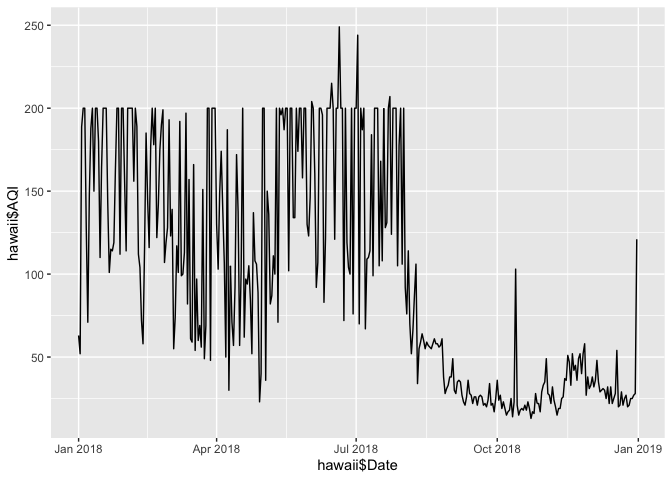

```r
aqi %>%
  filter(`county Name`== "Hawaii") -> hawaii
ggplot(hawaii,aes(x=hawaii$Date,y=hawaii$AQI)) + geom_line()
```

در سوال ۱، کالیفرنیا به عنوان آلوده ترین ایالت مشخص شد. حالا نمودار ستونی میانگین آلودگی مناطق مختلف کالیفرنیا را رسم کردیم.

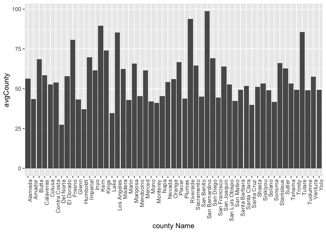

```r
aqi %>%
  filter(`State Name`=="California") %>%
  group_by(`county Name`) %>%
  summarise(avgCounty = mean(AQI)) %>%
  ggplot(aes(x=`county Name`,y=avgCounty)) + geom_bar(stat = "identity",position = "stack") + theme(axis.text.x = element_text(angle = 90, hjust = 1))
```

در سوال ۱، هاوایی به عنوان آلوده ترین منطقه با معیار میانیگین آلودگی مشخص شد. حالا نمودار ستونی تعداد تکرار نوع هوا بر حسب نوع هوا را رسم می کنیم.

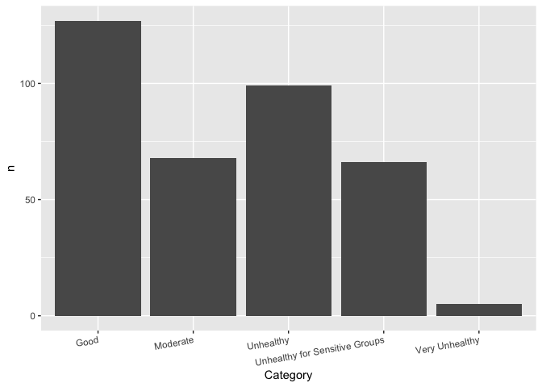

```r
aqi %>%
  filter(`county Name`=="Hawaii") %>%
  group_by(Category) %>%
  count() %>%
  ggplot(aes(x=Category,y=n)) + geom_bar(stat="identity") + theme(axis.text.x = element_text(angle = 10, hjust = 1))
```